# Causality: Changing Minds on Gay Marriage

Quantitative Methods for Humanities

CUNEF Universidad, 2024

# Prelude

To run this R Markdown notebook you need the **rmarkdown** package (`install.packages("rmarkdown")`) and to load the data from the local CSV file. Make sure your working directory points to the folder containing **gay.csv**.

```r
# Uncomment to install rmarkdown if necessary
# install.packages("rmarkdown")
# Load the data
gay <- read.csv("gay.csv", stringsAsFactors = TRUE)
```

# Introduction

In this case study, we analyze two field experiments that canvassed U.S. households on support for same-sex marriage. **Study 1 is the original** experiment, and **Study 2 is a follow-up replication that only uses gay canvassers**.

Within each study, **Wave 1 represents a baseline survey conducted before any canvassing**, and **Waves 2–7 (in Study 1) or Waves 2–4 (in Study 2) are follow-up surveys** administered at approximately two-month intervals to track both short- and long-term changes in attitudes.

Canvassers were randomly assigned to households and revealed their sexual orientation (gay vs. straight) during ≈20-minute conversations. Here, **“recycling script” refers to a neutral conversation** prompt—canvassers discuss residential recycling and environmental practices without addressing same-sex marriage. In contrast, the **“same-sex marriage (SSM) script” is a structured dialogue specifically designed to persuade or inform households about legalizing and supporting same-sex marriage**, delivered by either a gay or straight canvasser.

This case study tests the **contact hypothesis**, which posits that personal interactions with members of a stigmatized out-group (here, gay individuals) can reduce prejudice and change attitudes.

**Note:** Although the study was later retracted over data‐fabrication allegations, our focus is methodological: demonstrating how to analyze experimental data with causal inference tools.

# The data

The data frame **gay** contains 69592 observations and 4 variables:

| Variable | Description |
| --- | --- |
| `study` | Indicates experiment: 1 = original study, 2 = replication |
| `treatment` | Original treatment labels (long strings): e.g., “No Contact”, “Same-Sex Marriage Script by Gay Canvasser” |
| `wave` | Survey wave: 1 = baseline (pre-treatment); 2–7 = follow-ups at ~2-month intervals |
| `ssm` | Outcome: 1–5 Likert scale for support of same-sex marriage (higher = more supportive) |

This is an *experimental design*:

- **Treatment:** `treatment_short` (manipulation)
- **Outcome:** `ssm` (response)
- Randomization should balance baseline covariates across `treatment_short` levels.

## Data manipulation

For a shorter notation and more convenient manipulation of the variables, we recode the long-strings `treatment` variable into shorter entries. We store the values into a new variable called `treatment_short`, while keep the original values untouched in the `treatment` variable

```r
# Recode long treatment labels into short, analyzable codes
gay$treatment_short <- factor(
  gay$treatment,
  levels = c(
    "No Contact",
    "Recycling Script by Gay Canvasser",
    "Same-Sex Marriage Script by Gay Canvasser",
    "Recycling Script by Straight Canvasser",
    "Same-Sex Marriage Script by Straight Canvasser"
  ),
  labels = c(
    "control",
    "recycle_gay",
    "ssm_gay",
    "recycle_str",
    "ssm_str"
  )
)
```

## Data exploration

Inspect the first rows and summary statistics:

```r
# Peek at data structure and values
head(gay)
```

```
##   study  treatment wave ssm treatment_short
## 1     1 No Contact    3   5         control
## 2     1 No Contact    4   5         control
## 3     1 No Contact    1   5         control
## 4     1 No Contact    6   5         control
## 5     1 No Contact    2   5         control
## 6     1 No Contact    7   5         control
```

```r
summary(gay)
```

```
##      study                                                treatment
##  Min.   :1.000   No Contact                                    :37735
##  1st Qu.:1.000   Recycling Script by Gay Canvasser             : 6514
##  Median :1.000   Recycling Script by Straight Canvasser        : 6474
##  Mean   :1.149   Same-Sex Marriage Script by Gay Canvasser     :12452
##  3rd Qu.:1.000   Same-Sex Marriage Script by Straight Canvasser: 6417
##  Max.   :2.000
##       wave            ssm           treatment_short
##  Min.   :1.000   Min.   :1.000   control    :37735
##  1st Qu.:2.000   1st Qu.:1.000   recycle_gay: 6514
##  Median :4.000   Median :3.000   ssm_gay    :12452
##  Mean   :3.753   Mean   :3.107   recycle_str: 6474
##  3rd Qu.:5.000   3rd Qu.:5.000   ssm_str    : 6417
##  Max.   :7.000   Max.   :5.000
```

> *Comment:* Check that `treatment_short` values match the intended mapping and look for missing or unexpected values.

## Data analysis

We proceed through five steps: (1) randomization check, (2) short-term average treatment effects, (3) placebo comparison, (4) long-term persistence, (5) replication analysis.

## 1. Randomization Check (Study 1, Wave 1)

Verify that baseline support for SSM (`ssm`) is similar across treatment groups before any intervention.

```r
# Baseline subset for Study 1, wave 1
baseline1 <- gay[gay$study == 1 & gay$wave == 1, ]

# Group means
tapply(baseline1$ssm, baseline1$treatment_short, mean)
```

```
##     control recycle_gay     ssm_gay recycle_str     ssm_str
##    3.042764    3.130975    3.025195    3.013474    3.099710
```

```r
# Group standard deviations
tapply(baseline1$ssm, baseline1$treatment_short, sd)
```

```
##     control recycle_gay     ssm_gay recycle_str     ssm_str
##    1.680540    1.702533    1.666099    1.683483    1.682885
```

**Interpretation:** Similar means and variances across `control`, `recycle_gay`, and `ssm_gay` (and analogues) indicate successful randomization.

## 2. Average Treatment Effects (Study 1, Wave 2)

Compute the mean difference in support at two months post-treatment (wave 2) relative to control.

```r
# Wave 2 subset for Study 1
w2_1 <- gay[gay$study == 1 & gay$wave == 2, ]

# ATE: SSM script by gay canvasser vs. control
ate_gay <- mean(w2_1$ssm[w2_1$treatment_short == "ssm_gay"]) -
           mean(w2_1$ssm[w2_1$treatment_short == "control"])

# ATE: SSM script by straight canvasser vs. control
ate_straight <- mean(w2_1$ssm[w2_1$treatment_short == "ssm_str"]) -
                mean(w2_1$ssm[w2_1$treatment_short == "control"])

# Display ATEs
ate_gay
```

```
## [1] 0.09987463
```

```r
ate_straight
```

```
## [1] 0.122248
```

**Interpretation:**

- **ATE (ssm_gay):** 0.0999 points on a 1–5 scale.
- **ATE (ssm_str):** 0.1222 points on a 1–5 scale.

## 3. Comparison with Placebo Contact (Study 1, Wave 2)

Use recycling script as a control to isolate content effects from contact effects.

### (a) Purpose

The recycling script provides interpersonal engagement without SSM messaging, serving as a placebo.

### (b) SSM vs. Recycling, Gay Canvasser

```r
# Compare ssm_gay vs recycle_gay
gay_comp <- w2_1[w2_1$treatment_short %in% c("ssm_gay", "recycle_gay"), ]
mean(gay_comp$ssm[gay_comp$treatment_short == "ssm_gay"]) -
  mean(gay_comp$ssm[gay_comp$treatment_short == "recycle_gay"])
```

```
## [1] 0.03204239
```

### (c) SSM vs. Recycling, Straight Canvasser

```r
# Compare ssm_str vs recycle_str
str_comp <- w2_1[w2_1$treatment_short %in% c("ssm_str", "recycle_str"), ]
mean(str_comp$ssm[str_comp$treatment_short == "ssm_str"]) -
  mean(str_comp$ssm[str_comp$treatment_short == "recycle_str"])
```

```
## [1] 0.1575845
```

## 4. Long-Term Effects (Study 1, Waves 2–7)

Evaluate persistence of treatment effects up to one year post-intervention (wave 7).

```r
waves <- 2:7
ate_gay <- numeric(length(waves))
ate_str <- numeric(length(waves))
for (i in seq_along(waves)) {
  w <- waves[i]
  sub <- gay[gay$study == 1 & gay$wave == w, ]
  ate_gay[i] <- mean(sub$ssm[sub$treatment_short == "ssm_gay"]) -
                mean(sub$ssm[sub$treatment_short == "control"])
  ate_str[i] <- mean(sub$ssm[sub$treatment_short == "ssm_str"]) -
                mean(sub$ssm[sub$treatment_short == "control"])
}
# Summarize all waves
data.frame(
  wave = waves,
  ate_gay = round(ate_gay, 3),
  ate_straight = round(ate_str, 3)
)
```

```
##   wave ate_gay ate_straight
## 1    2   0.100        0.122
## 2    3   0.081        0.060
## 3    4   0.093        0.087
## 4    5   0.148        0.099
## 5    6   0.086        0.064
## 6    7   0.059       -0.043
```

We next make a plot to better answer some key questions, like:

- Are effects stable, increasing, or decaying over time?
- When do they peak?

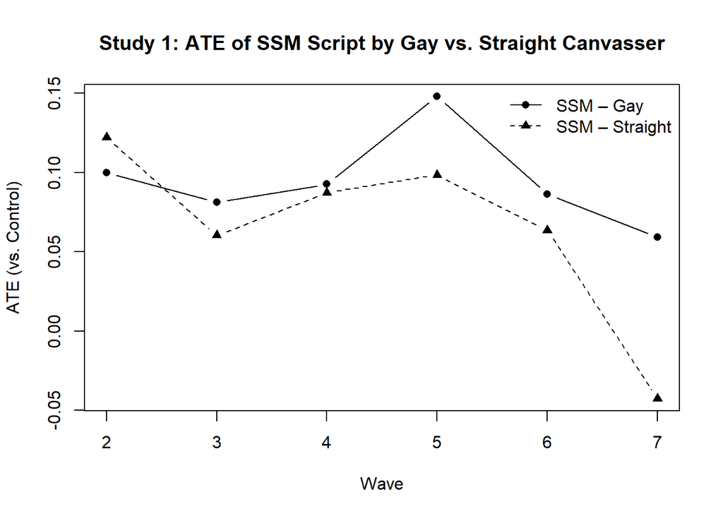

```r
# Plot ATE across waves for gay vs. straight canvassers
plot(waves, ate_gay, type = "b", pch = 16,
     ylim = range(c(ate_gay, ate_str)),
     xlab = "Wave", ylab = "ATE (vs. Control)",
     main = "Study 1: ATE of SSM Script by Gay vs. Straight Canvasser")
lines(waves, ate_str, type = "b", pch = 17, lty = 2)
legend("topright",
       legend = c("SSM – Gay", "SSM – Straight"),
       pch = c(16, 17), lty = c(1, 2),
       bty = "n")
```

## 5. Replication Analysis (Study 2)

Study 2 only uses gay canvassers with the SSM script. Repeat baseline checks and ATE estimation.

### (a) Baseline Randomization (Wave 1)

```r
baseline2 <- gay[gay$study == 2 & gay$wave == 1, ]
# Counts and means by group
table(baseline2$treatment_short)
```

```
##
##     control recycle_gay     ssm_gay recycle_str     ssm_str
##        1203           0        1238           0           0
```

```r
tapply(baseline2$ssm, baseline2$treatment_short, mean)
```

```
##     control recycle_gay     ssm_gay recycle_str     ssm_str
##    2.970075          NA    2.971729          NA          NA
```

### (b) ATE at Wave 2

```r
w2_2 <- gay[gay$study == 2 & gay$wave == 2, ]
ate2_w2 <- mean(w2_2$ssm[w2_2$treatment_short == "ssm_gay"]) -
           mean(w2_2$ssm[w2_2$treatment_short == "control"])
ate2_w2
```

```
## [1] 0.1238937
```

### (c) Follow-Up Effects (Waves 3–4)

```r
waves2 <- 2:4
ate2 <- sapply(waves2, function(w) {
  sub <- gay[gay$study == 2 & gay$wave == w, ]
  mean(sub$ssm[sub$treatment_short == "ssm_gay"]) -
    mean(sub$ssm[sub$treatment_short == "control"])
})
data.frame(wave = waves2, ate_gay = round(ate2, 3))
```

```
##   wave ate_gay
## 1    2   0.124
## 2    3   0.150
## 3    4   0.125
```

**Conclusion:** Assess consistency of Study 2 effect sizes and longevity compared to Study 1.

# References

These notes adapt the original gay canvassing experiments. See Sheets & Kalla (2017), “Reducing exclusionary attitudes through interpersonal contact.”